# Tidybiology Final Project: Creating heatmap of RNA-seq data

Min Jin Lee

October 21, 2019

### Install additional packages

```r
install.packages("hrbrthemes")
install.packages("plotly")
install.packages("d3heatmap")
install.packages("heatmaply")
install.packages("gplots")
```

### Import data

I used publicly available RNA-seq datasets of *in vitro* calcium-mediated keratinocyte differentiton shared by Bin, et. al., 2016 (GSE73305). There were total of 6 conditions. US (unstimulated), D1 (1 day post induction), D2 (2 days post induction), …, D5(5 days post induction). The differential gene expression was calculated using the unstimulated control. The data clean-up process was performed by our colaborator, Dr. David Corcoran. I created csv files for each time point to upload.

```r
#IMPORT YOUR DATA
#MAKE SURE TO GET THE CODE CHUNK OPTIONS SET
D1vsUS_GSE73305 <- read.csv("/cloud/project/6_final/D1vsUS_GSE73305.csv")
D2vsUS_GSE73305 <- read.csv("/cloud/project/6_final/D2vsUS_GSE73305.csv")
D3vsUS_GSE73305 <- read.csv("/cloud/project/6_final/D3vsUS_GSE73305.csv")
D4vsUS_GSE73305 <- read.csv("/cloud/project/6_final/D4vsUS_GSE73305.csv")
D5vsUS_GSE73305 <- read.csv("/cloud/project/6_final/D5vsUS_GSE73305.csv")
```

### Take a `glimpse` into the data in the dataframe

The dataset looks like this:

```r
glimpse(D1vsUS_GSE73305)
```

```
## Observations: 17,250
## Variables: 8
## $ geneID         <fct> ENSG00000176971, ENSG00000095739, ENSG00000107731…
## $ geneName       <fct> FIBIN, BAMBI, UNC5B, FAM102B, ZMYND15, VLDLR-AS1,…
## $ baseMean       <dbl> 35.96243, 1111.88846, 3411.88851, 83.31907, 54.99…
## $ log2FoldChange <dbl> 8.261582, 3.600047, 3.952167, -3.013279, 3.483357…
## $ lfcSE          <dbl> 2.9018725, 1.3482647, 1.4931481, 1.1790080, 1.367…
## $ stat           <dbl> 2.846983, 2.670133, 2.646869, -2.555775, 2.547251…
## $ pvalue         <dbl> 0.004413573, 0.007582110, 0.008124081, 0.01059516…
## $ padj           <dbl> 0.9997503, 0.9997503, 0.9997503, 0.9997503, 0.999…
```

Next, I trimmed my datasets to extract only two variables: geneName and log2FoldChnage.

Next, I joined the datasets.

## EDA Graph

For my analysis, I ploted selected antiviral genes (AVPs).

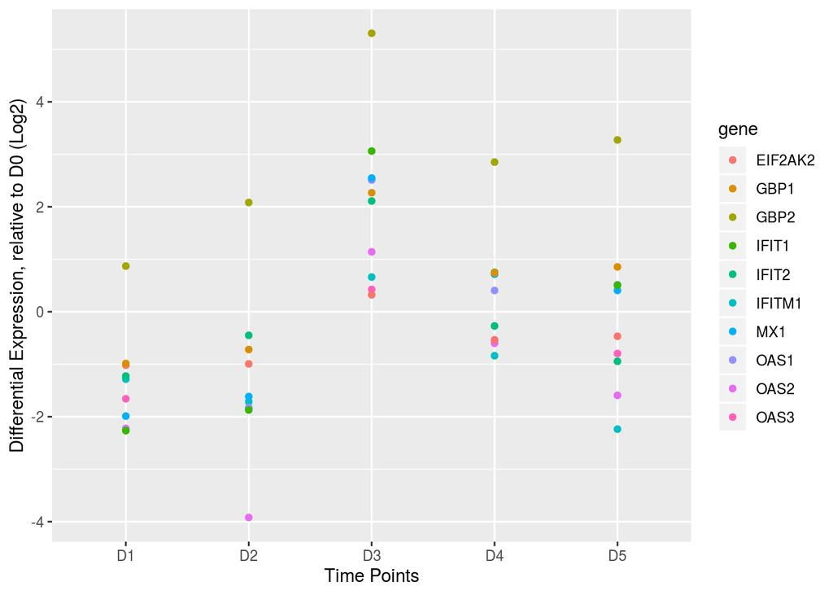

## Next step

I decided to create a heatmap using AVPs as well as some keratinocyte differentiation markers

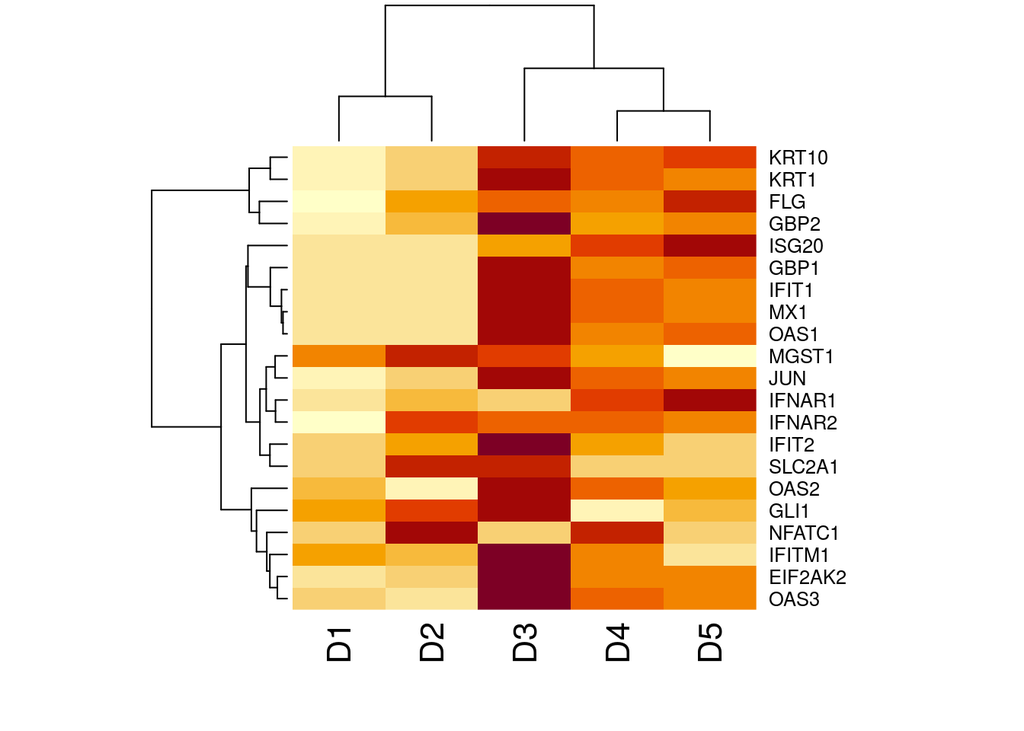

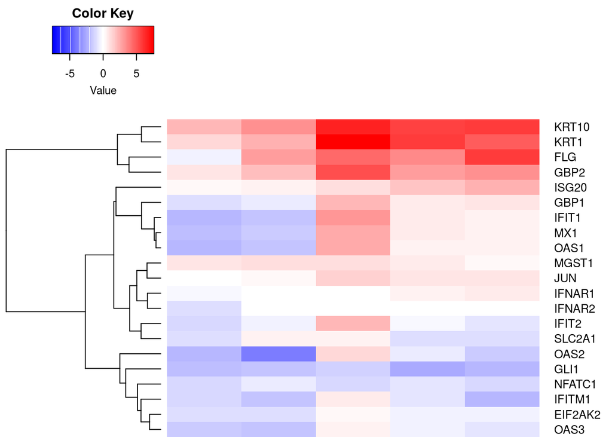

## Final Graph

I created an interactive heatmap.

[interactive chart not shown]

## Conclusions

Analysis of extracted result shows evidence that calcium-mediated differentiation of kertinocytes modulate transcription of some antiviral genes.

## Acknolwedgements

I would like to thank Dr. Hirschey, Dr. Mill, and Dr. Bareja for giving me this basig course and tools for data analysis using r. I would also like to acknowledge Dr. Corcoran for providing the datasets. I’m grateful for the packages and libraries I used, and also numerous help I received online.